# Valoración de las áreas verdes por parte de los estudiantes de la UTEC.

**Modelo binomial y geométrico para tiempo**

Según la Organización Mundial de la Salud y el European Common Indicator de la Unión Europea, recomiendan que en una ciudad sostenible los habitantes no deben vivir a más de 15 minutos de un parque (Gadea, 2021). Dada esta información se plantea un modelo binomial negativo para calcular la probabilidad de tener que encuestar alumnos hasta encontrar a uno que viva a más de 15 minutos de un parque, analizaremos el modelo como un indicador de la sostenibilidad de Lima (tomando en cuenta que el resultado no será del todo correcto por la falta de representatividad para distritos)

```r
parque_15<-filter(DF,DF$Tiempo>=15)
sum(table(parque_15$Tiempo))
```

```
## [1] 37
```

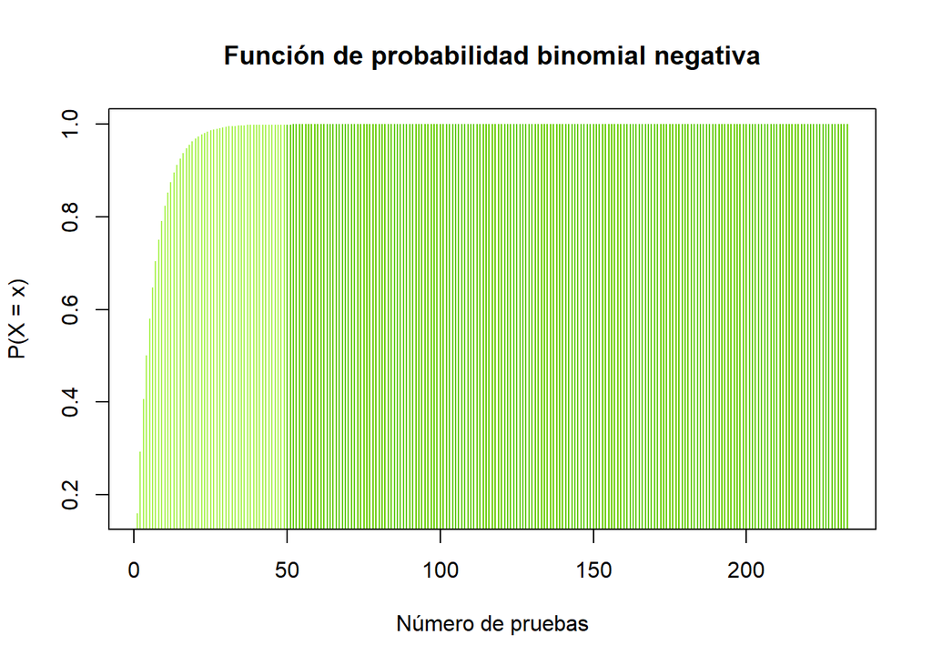

```r
x=0:232
my_color=ifelse(x<=48,"#AEF359","#66CD00")

plot(pnbinom(x,1,37/232),type = "h", lwd = 1,col=my_color,
     main = "Función de probabilidad binomial negativa",
     ylab = "P(X = x)", xlab = "Número de pruebas")
```

De igual manera se realizó el modelo geométrico para el mismo caso, donde los gráficos deben ser iguales (solo para el caso de éxitos igual a 1), este gráfico solo se realizó para visualizar la similitud entre los modelos.

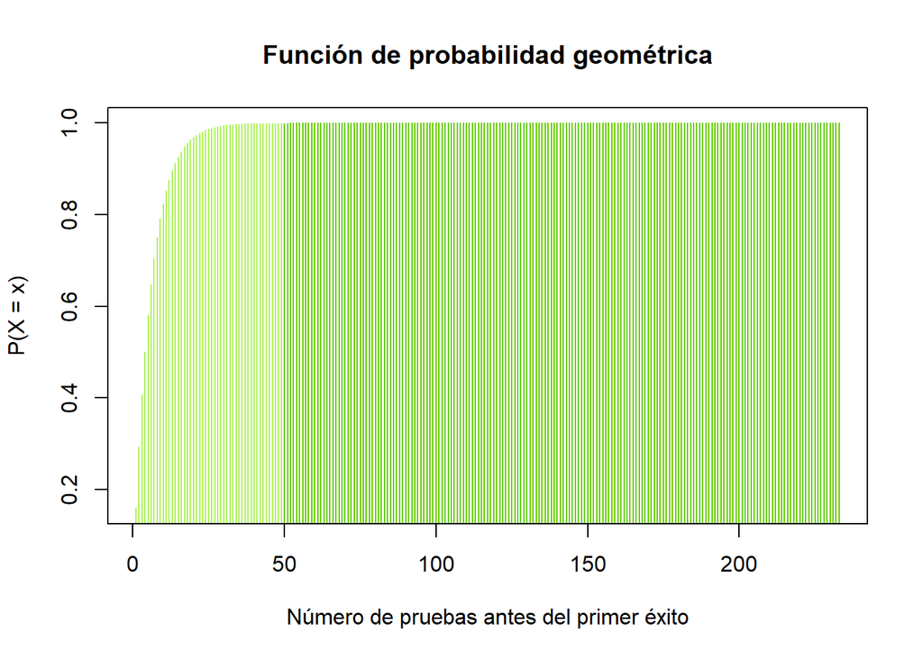

```r
plot(pgeom(x,37/232 ),type = "h", lwd = 1,col=my_color,
     main = "Función de probabilidad geométrica",
     ylab = "P(X = x)", xlab = "Número de pruebas antes del primer éxito")
```

**Modelos Binomial para valoración de la carrear de electrónica**

La Universidad de Ingeniería y Tecnología está buscando estudiantes que puedan hacer un voluntariado, el cual consiste en realizar un mantenimiento general de las áreas verdes que tiene la universidad. Participar en este voluntariado es opcional para alumnos regulares. Sin embargo, los alumnos que hayan maltratado las áreas verdes dentro de la universidad deberán ser parte de este servicio estudiantil obligatoriamente, el cual será su proceso disciplinario.

Se sabe que aproximadamente el 10.73 % de los estudiantes encuestados pusieron una valoración menor a 3. Calcule la probabilidad de que en una muestra de 25 estudiantes se encuentren a 5 estudiantes de la carrera de ingeniería electrónica que tengan una valoración menor a 3.

Datos: - El 10.73 % de los estudiantes tiene una valoración menor a 3. - En total hay 25 estudiantes con una valoración menor a 3. - Existen exactamente 5 estudiantes de la carrera de Ingeniería Electrónica que pusieron una valoración menor a 3.

Argumento: La universidad se ha propuesto fomentar la valoración de las áreas verdes en estudiantes que pertenecen a la carrera de Ingeniería Electrónica, ya que los resultados estadísticos con las variables carrera y valoración a las áreas verdes nos muestra que los estudiantes de esta carrera profesional tiene el menor promedio de valoración en comparación con las demás carreras existentes en la universidad.

```r
CS <- filter(DF , DF$Valoracion == "1" | DF$Valoracion == "2")
table(DF$Carrera)
```

```
##
## Administración y negocios digitales                       Bioingenieria
##                                  10                                  20
##                    Ciencia de datos          Ciencias de la computación
##                                  11                                  29
##                Ingeniería ambiental                    Ingeniería civil
##                                  15                                  29
##            Ingeniería de la energía              Ingeniería electrónica
##                                  10                                  13
##               Ingeniería Industrial                 Ingeniería mecánica
##                                  40                                  16
##              Ingeniería mecatrónica                  Ingeniería química
##                                  29                                  10
```

```r
round(dbinom(5,25,0.1073),2)
```

```
## [1] 0.08
```

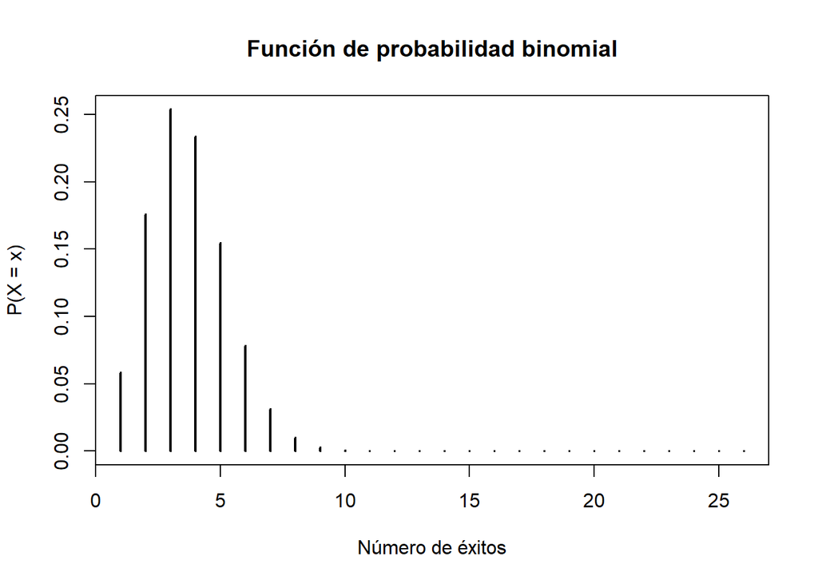

```r
x <- 0:25
plot(dbinom(x, size = 25 , prob = 0.1073), type = "h", lwd = 2,
     main = "Función de probabilidad binomial",
     ylab = "P(X = x)", xlab = "Número de éxitos")
```

## 4.3 Análisis de modelo continuo

Es sabido que los espacios verdes aportan beneficios sobre la salud. Bajo esta premisa, un grupo de investigadores de la Escuela de Medicina de la Universidad de Exeter, en Reino Unido y la Universidad de Uppsala, en Suecia, empezaron a visitar un parque con cierta frecuencia y duración. Al principio no se encontraron beneficios significativos para la salud o el bienestar, sin embargo, una vez que los participantes alcanzaron un promedio de 2 horas semanales, empezaron a ver cambios significativos en el bienestar social y emocional de los participantes (Salud Digital, s/f, p.1). Si se sabe que en promedio las personas (estudiantes, niños, adultos, etc.) tienen que ir 2 horas semanales a las áreas verdes para mantenerse en un buen estado emocional y social. ¿Cual es la probabilidad de que los estudiantes encuestados pasen entre 0.5 a 1.5 horas a las semana en las áreas verdes? - El problema planteado tiene una forma exponencial, ya que involucra variables de tiempo media e intervalos de tiempo. - La probabilidad acumulada es mayor a 0 y menor a 1. - La constante que acompaña a “X” en el exponente es la inversa de la constante que acompaña e (número de Euler).

```r
round(pexp(1.5-0.5,1/2),2)
```

```
## [1] 0.39
```

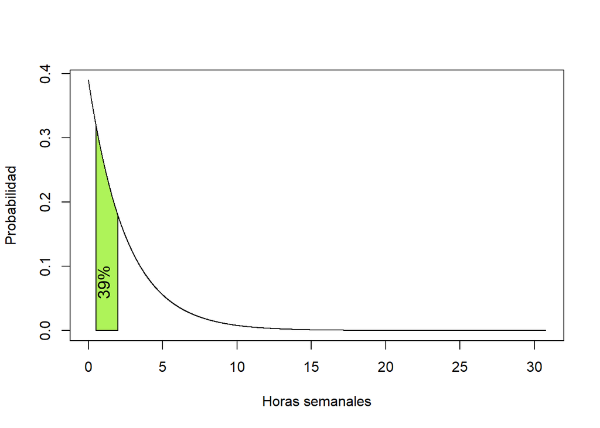

```r
exp_area <- function(rate = 1, lb, ub, acolor = "lightgray", ...) {
    x <- seq(0, 12/rate, 0.01)

    if (missing(lb)) {
       lb <- min(x)
    }
    if (missing(ub)) {
        ub <- max(x)
    }

    x2 <- seq(lb, ub, length = 100)
    plot(x, dexp(x, rate = rate), type = "n", xlab = "Horas semanales", ylab = "Probabilidad")

    y <- dexp(x2, rate = rate)
    polygon(c(lb, x2, ub), c(0, y, 0), col = acolor)
    lines(x, dexp(x, rate = rate), type = "l", ...)
}
exp_area(rate = 0.39, lb = 0.5 , ub = 2, acolor = "#AEF359")
text(1, 0.075, "39%", srt = 90, col = "black", cex = 1.2)
```

# 5 **Conclusiones**

- Se logró ver una pequeña tendencia las mujeres valoran más que los hombres, esto fue corroborado con las fuentes consultadas.
- En la gráfica valoración - carrera se observa que la carrera que más valora las áreas verdes es Ingeniería Ambiental. Esto tiene sentido ya que en la carrera se ven temas relacionados con el medio ambiente desde el primer ciclo, esto desarrolla en los alumnos una valoración mayor hacia los temas ambientales.
- La gráfica valoración - alumnos muestra que la mayoría de los alumnos valora las áreas verdes con 5, debido a que hay más alumnos de las carreras que valoran con 5.
- El perfil de estudiante que valora menos sería un alumno de ingeniería electrónica y el que valora más sería un alumno de ingeniería ambiental.
- Se comparó los datos de la encuesta sobre el parque más cercano a la vivienda en Lima del estudiante y lo que señala la Organización mundial de la Salud como adecuado acerca de la proximidad de las áreas verdes a las viviendas se concluyó que Lima no es una ciudad sostenible.
- Se hallaron las probabilidades de valoración ambiental por carrera y se halló que todos los alumnos de Ingeniería ambiental valoraron con 5
- Se plantearon escenarios imaginarios para ver el compromiso de los estudiantes con el medio ambiente y se concluyó que el dinero, la valoración tienen bastante relación.
- A partir del análisis exploratorio de las variables se pudo comprobar que la valoración a las áreas verdes y la profesión que estudian los estudiantes encuestados tienen una relación muy estrecha.

# 6 **Referencias bibliográficas**

Asociación Peruana de Empresas de Inteligencia de Mercados. (2021). *Niveles socioeconómicos 2021*. Asociación Peruana de Empresas de Inteligencia de Mercados. Recuperado de: http://apeim.com.pe/wp-content/uploads/2021/10/niveles-socioecono%CC%81micos-apeim-v2-2021.pdf

Gadea, T. (2021). *La OMS nunca recomendó cuántos espacios verdes debe tener una ciudad, cuánto importa la cantidad y calidad de estos en Buenos Aires* . Chequeado. Recuperado de: https://chequeado.com/el-explicador/la-oms-nunca-recomendo-cuantos-espacios-verdes-debe-tener-una-ciudad-cuanto-importa-la-cantidad-y-calidad-de-estos-en-buenos-aires/

Ministerio del Ambiente. (2015). *Manual de valoración económica del patrimonio natural*. Ministerio del Ambiente. Recuperado de: https://www.minam.gob.pe/patrimonio-natural/wp-content/uploads/sites/6/2013/09/MANUAL-VALORACI%C3%93N-14-10-15-OK.pdf

RPP. (2020). *Áreas verdes: Lima tiene un déficit de 56 millones de metros cuadrados*. RPP. Recuperado de: https://rpp.pe/peru/actualidad/areas-verdes-lima-tiene-un-deficit-de-56-millones-de-metros-cuadrados-noticia-1242505?ref=rpp

SALUD DIGITAL. (2022). *¿Cuánto tiempo se recomienda pasar al aire libre?*. Recuperado de: https://www.clikisalud.net/cuanto-tiempo-pasar-al-aire-libre/

Pinto, E. (2016). *Análisis de la Percepción Ambiental y Valoración Económica de las Áreas Verdes Urbanas de Uso Público en tres distritos de Lima Metropolitana*. Recuperado de: http://repositorio.lamolina.edu.pe/handle/20.500.12996/3122